# CausalML Lecture 1 — Demo

**Drew Dimmery**

We will simulate a randomised experiment and study the difference-in-means estimator. The goal is to see one specific thing clearly:

> The same variance estimator is conservative for the SATE and exactly right for the PATE. The difference between the two is a quantity we can never estimate.

## Setup Instructions

This notebook runs in the shared `lecture-slides` environment, managed with [uv](https://docs.astral.sh/uv/).

1. **Install uv** (if not already installed):

   ```
   curl -LsSf https://astral.sh/uv/install.sh | sh
   ```

2. **Navigate to the repository root** (the directory containing `pyproject.toml`):

   ```
   cd lecture-slides
   ```

3. **Install dependencies**:

   ```
   uv sync
   ```

4. **Register the Jupyter kernel** (once):

   ```
   make kernel
   ```

5. **Start Jupyter**:

   ```
   uv run jupyter notebook
   ```

6. **Select the kernel**: In Jupyter, go to Kernel → Change Kernel → "cml26-lectures"

Dependencies are declared in the repository's `pyproject.toml`. You can see the contents of that file here:

```python
with open('../pyproject.toml', 'r') as f:
    print(f.read())
```

```
[project]
name = "lecture-slides"
version = "0.1.0"
description = "Causal Machine Learning lecture slides and demos"
requires-python = ">=3.12"
dependencies = [
    "ipykernel>=6.29",
    "jupyter>=1.1",
    "matplotlib>=3.9",
    "numpy>=2.0",
    "pandas>=2.0",
    "plotnine>=0.14",
    "polars>=1.0",
    "pyarrow>=17",
    "pyyaml>=6.0",
]

[dependency-groups]
dev = ["ruff>=0.8"]

[build-system]
requires = ["setuptools>=75"]
build-backend = "setuptools.build_meta"

[tool.setuptools.packages.find]
where = ["src"]

[tool.setuptools.package-data]
cml26 = ["*.css"]

[tool.ruff]
src = ["src"]

[tool.ruff.lint]
select = ["E", "F", "I", "UP"]
```

## Simulation Plan

Write the plan before the code. We use the **ADEMP** structure from [Morris, White and Crowther (2019)](https://doi.org/10.1002/sim.8086), as on the slides.

### Aims

Understand how sample-based and population-based inference for average treatment effects relate. Three questions:

1. Is the difference in means unbiased for the SATE and the PATE?
2. How conservative is Neyman's variance estimator, and why?
3. What does consistency fix, and what does it leave alone?

### Data-generating mechanism

A fixed population $\mathcal{U}$, a simple random sample $\mathcal{S}$ from it without replacement, and a completely randomised experiment within $\mathcal{S}$:

$$X_i \sim \text{Uniform}(0, 5)$$

$$Y_i(0) = 10 - \exp\left(\frac{X_i}{3}\right) + \varepsilon_{i0}, \quad \varepsilon_{i0} \sim \mathcal{N}(0, 0.2^2)$$

$$Y_i(1) = 10 - \exp\left(\frac{X_i}{5}\right) + \varepsilon_{i1}, \quad \varepsilon_{i1} \sim \mathcal{N}(0, 0.2^2)$$

The unit-level effect is $\tau_i = \exp(X_i/3) - \exp(X_i/5) + (\varepsilon_{i1} - \varepsilon_{i0})$, so effects vary across units. Since we wrote the DGP, we can compute the *superpopulation* average effect exactly:

$$\mathbb{E}[\tau_i] = \mathbb{E}\!\left[e^{X/3}\right] - \mathbb{E}\!\left[e^{X/5}\right] = \tfrac{3}{5}\left(e^{5/3} - 1\right) - \left(e^{1} - 1\right) \approx 0.8584.$$

Three different "truths" appear below. Keep them apart:

| Quantity | Symbol | Random? | Fixed by |
| --- | --- | --- | --- |
| Superpopulation ATE | $\mathbb{E}[\tau_i]$ | no | the DGP |
| Population ATE | $\tau$ (PATE) | no, once $\mathcal{U}$ is drawn | the population we generated |
| Sample ATE | $\tau_{\mathcal{S}}$ (SATE) | **yes** | the sampling design |

### Estimand

The average treatment effect. Which average is the question. We study the sampling distribution of $\hat{\tau} = \bar{Y}_1 - \bar{Y}_0$ relative to both the SATE and the PATE.

### Methods

The difference in means with Neyman's variance estimator, $\hat{V} = s_1^2/N_1 + s_0^2/N_0$.

### Performance

One measure per question:

- **Bias:** $\mathbb{E}[\hat{\tau}] - \tau$, reported with Monte Carlo error.
- **Variance ratio:** $\mathbb{E}[\hat{V}] / \text{Var}[\hat{\tau}]$. One means honest standard errors; above one means conservative.
- **Coverage:** share of nominal 95% intervals containing the target.

## Simulation

### Set up the environment

The tools:

- [`numpy`](https://numpy.org/doc/stable/) for numerical computation.
- [`polars`](https://docs.pola.rs/) for dataframes. A little finicky, but fast.
- [`plotnine`](https://plotnine.readthedocs.io/), which is `ggplot2` for Python.
- `cml26`, the class package in `src/cml26/`. `apply_style()` sets the house theme for `plotnine` and `matplotlib`. `COLORS` is the palette: use `COLORS["truth"]` for true values and `COLORS["estimate"]` for estimated ones, and readers will follow without being told.

Two habits:

1. **Seed through a single generator.** `np.random.default_rng(seed)` returns a generator you pass explicitly to anything that needs randomness. Nothing can consume randomness behind your back, which is what makes the simulation reproducible.
2. **Name your simulation sizes** at the top, so you can change them later.

```python
import numpy as np
import polars as pl
import plotnine as p9

from cml26 import COLORS, apply_style, scale_color_cml, scale_fill_cml

apply_style()
pl.Config.set_tbl_cols(12)  # show all columns of the wider tables below

# One generator, passed explicitly to everything below.
rng = np.random.default_rng(12345)
```

### Data-generating functions

Each function is one source of randomness, and they compose in the order of the design: population $\to$ sample $\to$ assignment. Keeping them separate lets us hold one fixed while varying another, which is what the rest of the notebook does.

```python
def draw_potential_outcomes(shape, rng):
    """The DGP. `shape` may be an int or a tuple, so we can draw grids of samples later."""
    x = rng.uniform(0, 5, size=shape)
    y0 = 10 - np.exp(x / 3) + rng.normal(0, 0.2, size=shape)
    y1 = 10 - np.exp(x / 5) + rng.normal(0, 0.2, size=shape)
    return x, y0, y1


def generate_population(n_pop, rng):
    """Draw a fixed population of potential outcomes."""
    x, y0, y1 = draw_potential_outcomes(n_pop, rng)
    return pl.DataFrame({"x": x, "y0": y0, "y1": y1})


def srswor(n, population, rng):
    """Simple random sample of size n, without replacement."""
    idx = rng.choice(population.height, size=n, replace=False)
    return population[idx]


def rct(n1, sample, rng):
    """Completely randomised assignment of exactly n1 units to treatment."""
    n = sample.height
    a = np.zeros(n, dtype=int)
    a[:n1] = 1
    a = rng.permutation(a)
    # Only one potential outcome is revealed:
    y = np.where(a == 1, sample["y1"], sample["y0"])
    return sample.with_columns(a=a, y=y)


def diff_in_means(experiment):
    """The estimator: difference in means between treated and control."""
    y_t = experiment.filter(pl.col("a") == 1)["y"]
    y_c = experiment.filter(pl.col("a") == 0)["y"]
    return y_t.mean() - y_c.mean()
```

## Exploration

### Properties of the population

Start with the fixed properties of the population. Once we generate it, these are not random at all.

Population, sample and treatment-group sizes are parameters, so we can change them and see what happens. Note that the population is much larger than the sample ($N / |\mathcal{U}| = 2\%$). That makes the finite-population correction for sampling without replacement negligible, so the algebra from the slides applies directly. We return to this at the end.

```python
N_POPULATION = 2_000
N_SAMPLE = 40
N_TREATED = 20

# The superpopulation ATE, known exactly because we wrote the DGP:
ATE_SUPERPOPULATION = 0.6 * (np.exp(5 / 3) - 1) - (np.exp(1) - 1)
print(f"Superpopulation ATE, E[tau_i]: {ATE_SUPERPOPULATION:0.4f}")
```

```
Superpopulation ATE, E[tau_i]: 0.8584
```

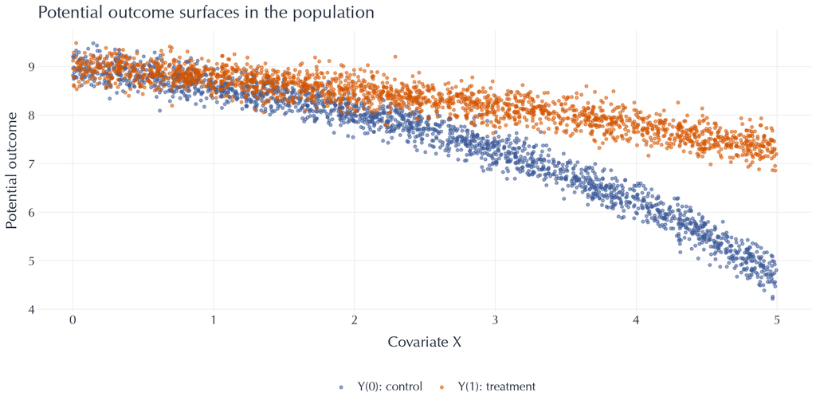

```python
P = generate_population(N_POPULATION, rng)

# Long format: one row per (unit, potential outcome). Easier to plot.
P_long = P.unpivot(
    on=["y0", "y1"], index="x", variable_name="po", value_name="value"
).with_columns(
    surface=pl.col("po").replace_strict({"y0": "Y(0): control", "y1": "Y(1): treatment"})
)

(
    p9.ggplot(P_long, p9.aes(x="x", y="value", color="surface"))
    + p9.geom_point(size=0.8, alpha=0.5)
    + scale_color_cml()
    + p9.labs(
        title="Potential outcome surfaces in the population",
        x="Covariate X",
        y="Potential outcome",
        color="",
    )
)
```

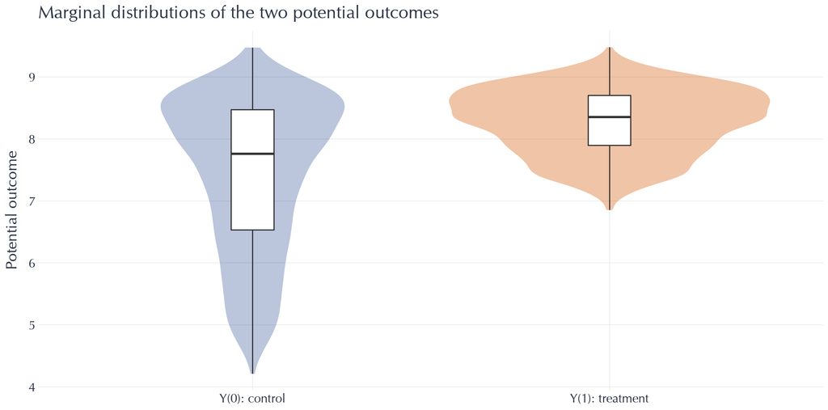

```python
(
    p9.ggplot(P_long, p9.aes(x="surface", y="value", fill="surface"))
    + p9.geom_violin(alpha=0.35, color="none")
    + p9.geom_boxplot(width=0.12, fill="white", outlier_size=0.5)
    + scale_fill_cml(guide=None)
    + p9.labs(
        title="Marginal distributions of the two potential outcomes",
        x="",
        y="Potential outcome",
    )
)
```

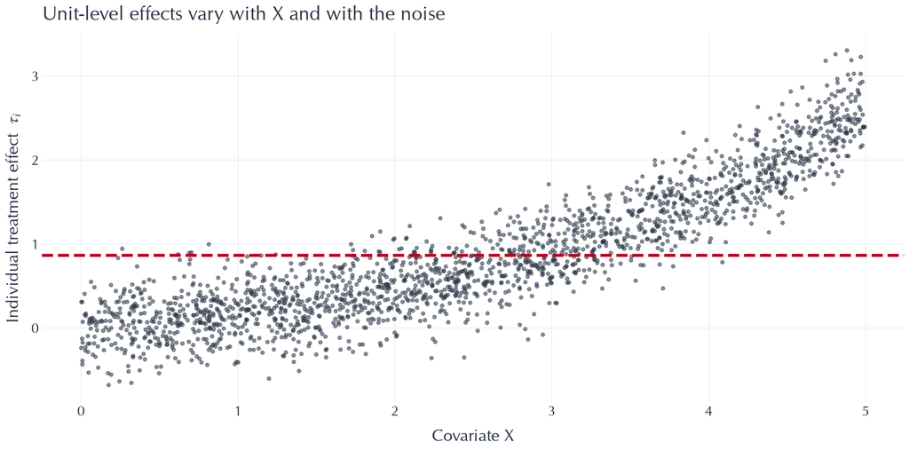

```python
(
    p9.ggplot(P, p9.aes(x="x", y="y1 - y0"))
    + p9.geom_point(size=0.8, alpha=0.5, color=COLORS["data"])
    + p9.geom_hline(
        yintercept=ATE_SUPERPOPULATION, color=COLORS["truth"], size=1.2, linetype="dashed"
    )
    + p9.labs(
        title="Unit-level effects vary with X and with the noise",
        x="Covariate X",
        y=r"Individual treatment effect  $\tau_i$",
    )
)
```

The vertical scatter at any given $X$ comes from $\varepsilon_{i1} - \varepsilon_{i0}$: the two potential outcomes have independent noise. No covariate can predict it, and no experiment can observe it, because we only ever see one of the two draws per unit. This is what will make our standard errors conservative.

```python
pate = (P["y1"] - P["y0"]).mean()
s2_tau_population = (P["y1"] - P["y0"]).var()

print(f"Population Average Treatment Effect (PATE): {pate:0.4f}")
print(f"Superpopulation ATE:                        {ATE_SUPERPOPULATION:0.4f}")
print(f"Variance of unit-level effects, sigma^2_tau: {s2_tau_population:0.4f}")
```

```
Population Average Treatment Effect (PATE): 0.8483
Superpopulation ATE:                        0.8584
Variance of unit-level effects, sigma^2_tau: 0.6177
```

The PATE is close to the superpopulation ATE but not equal to it, because drawing $|\mathcal{U}| = 2{,}000$ units is itself random. From here on $\mathcal{U}$ is fixed, so the PATE is a number, not a random variable.

### One sample

Take one sample and look at its Sample Average Treatment Effect (SATE):

```python
S = srswor(N_SAMPLE, P, rng)
sate = (S["y1"] - S["y0"]).mean()

print(f"The SATE is: {sate:0.4f}")
print(f"The PATE is: {pate:0.4f}")
```

```
The SATE is: 0.7942
The PATE is: 0.8483
```

Not the same. Why?

### Two sources of uncertainty

These two are distinct, and they behave differently:

1. **Sampling-based uncertainty**: $\tau_{\mathcal{S}} \neq \tau$. The SATE moves as we draw different samples. This exists even if we could see both potential outcomes for everyone in the sample.
2. **Design-based uncertainty**: $\hat{\tau} \neq \tau_{\mathcal{S}}$. The estimate moves as we re-randomise treatment within a fixed sample. This exists even if we sample the whole population.

Total uncertainty is the sum of the two, by the ANOVA decomposition on the slides. We isolate them one at a time: first vary the assignment with $\mathcal{S}$ fixed, then vary both.

Here is the sample against the population it came from:

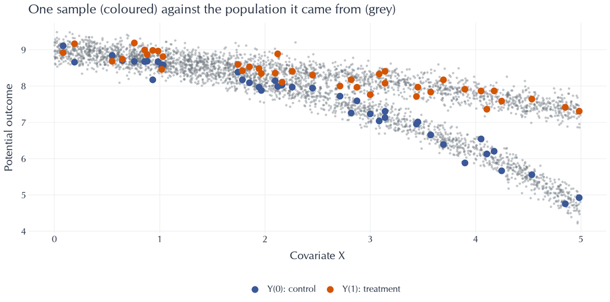

```python
S_long = S.unpivot(
    on=["y0", "y1"], index="x", variable_name="po", value_name="value"
).with_columns(
    surface=pl.col("po").replace_strict({"y0": "Y(0): control", "y1": "Y(1): treatment"})
)

(
    p9.ggplot(S_long, p9.aes(x="x", y="value", color="surface"))
    + p9.geom_point(
        data=P_long,
        mapping=p9.aes(x="x", y="value"),
        color=COLORS["neutral"],
        size=0.5,
        alpha=0.3,
        inherit_aes=False,
    )
    + p9.geom_point(size=3)
    + scale_color_cml()
    + p9.labs(
        title="One sample (coloured) against the population it came from (grey)",
        x="Covariate X",
        y="Potential outcome",
        color="",
    )
)
```

How different could the SATE have been? We know both potential outcomes for every unit in the population, so we can draw many samples and look.

```python
n_sate_draws = 10_000
sate_draws = np.empty(n_sate_draws)
for i in range(n_sate_draws):
    sample = srswor(N_SAMPLE, P, rng)
    sate_draws[i] = (sample["y1"] - sample["y0"]).mean()

sate_df = pl.DataFrame({"sate": sate_draws})
print(f"Mean SATE across {n_sate_draws:,} samples: {sate_draws.mean():0.4f}  (PATE = {pate:0.4f})")
print(f"Var[SATE]:                          {sate_draws.var(ddof=1):0.5f}")
print(f"sigma^2_tau / N:                    {s2_tau_population / N_SAMPLE:0.5f}")
```

```
Mean SATE across 10,000 samples: 0.8472  (PATE = 0.8483)
Var[SATE]:                          0.01534
sigma^2_tau / N:                    0.01544
```

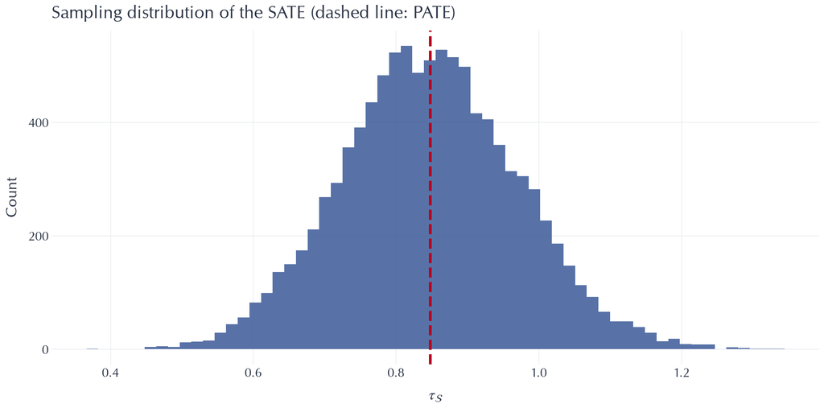

```python
(
    p9.ggplot(sate_df, p9.aes(x="sate"))
    + p9.geom_histogram(bins=60, fill=COLORS["control"], alpha=0.85)
    + p9.geom_vline(xintercept=pate, color=COLORS["truth"], size=1.2, linetype="dashed")
    + p9.labs(
        title="Sampling distribution of the SATE (dashed line: PATE)",
        x=r"$\tau_\mathcal{S}$",
        y="Count",
    )
)
```

## Run an RCT on the sample

```python
S = srswor(N_SAMPLE, P, rng)
sate = (S["y1"] - S["y0"]).mean()  # a new sample, so a new SATE
E = rct(N_TREATED, S, rng)

print(f"Sample size:        {E.height}")
print(f"Number treated:     {E['a'].sum()}")
print(f"Number in control:  {(1 - E['a']).sum()}")
```

```
Sample size:        40
Number treated:     20
Number in control:  20
```

### Neyman's variance estimator

From the slide "Inference for SATE or PATE":

$$\hat{V} = \frac{s_1^2}{N_1} + \frac{s_0^2}{N_0}$$

where $s_1^2$ and $s_0^2$ are the sample variances of the observed outcomes in each arm. It has three interpretations, and all three are true at once:

1. A **conservative approximation** of the randomisation variance relative to the SATE, for arbitrary effects.
2. **Unbiased** for that randomisation variance when the effect is constant.
3. **Unbiased** for the total (sampling + randomisation) variance relative to the PATE, for arbitrary effects.

In code:

```python
def neyman_variance(experiment):
    """Neyman's variance estimator for the difference in means."""
    y_t = experiment.filter(pl.col("a") == 1)["y"].to_numpy()
    y_c = experiment.filter(pl.col("a") == 0)["y"].to_numpy()
    return y_t.var(ddof=1) / y_t.size + y_c.var(ddof=1) / y_c.size
```

```python
ate_hat = diff_in_means(E)
se_hat = np.sqrt(neyman_variance(E))

print(f"Estimate:      {ate_hat:0.4f} +/- {se_hat:0.4f}")
print(f"True SATE:     {sate:0.4f}   (error: {ate_hat - sate:+0.4f} = {(ate_hat - sate) / se_hat:+0.2f} SE)")
print(f"True PATE:     {pate:0.4f}   (error: {ate_hat - pate:+0.4f} = {(ate_hat - pate) / se_hat:+0.2f} SE)")
```

```
Estimate:      1.5182 +/- 0.3193
True SATE:     0.9973   (error: +0.5209 = +1.63 SE)
True PATE:     0.8483   (error: +0.6699 = +2.10 SE)
```

### What we actually observe

Filled points are the outcomes we observed. Hollow points are the counterfactuals for the same units: real values in the population we drew, which the experiment does not reveal. The line joining each pair is that unit's treatment effect $\tau_i$, which no experiment measures directly.

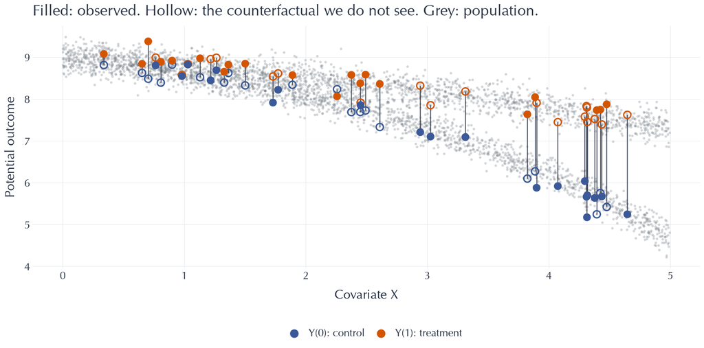

```python
observed = E.select(
    "x",
    value="y",
    surface=pl.when(pl.col("a") == 1)
    .then(pl.lit("Y(1): treatment"))
    .otherwise(pl.lit("Y(0): control")),
)
counterfactual = E.select(
    "x",
    value=pl.when(pl.col("a") == 1).then(pl.col("y0")).otherwise(pl.col("y1")),
    surface=pl.when(pl.col("a") == 1)
    .then(pl.lit("Y(0): control"))
    .otherwise(pl.lit("Y(1): treatment")),
)
pairs = E.select("x", y_obs="y", y_cf=counterfactual["value"])

(
    p9.ggplot(observed, p9.aes(x="x", y="value", color="surface"))
    + p9.geom_point(
        data=P_long,
        mapping=p9.aes(x="x", y="value"),
        color=COLORS["neutral"],
        size=0.4,
        alpha=0.2,
        inherit_aes=False,
    )
    + p9.geom_segment(
        data=pairs,
        mapping=p9.aes(x="x", xend="x", y="y_obs", yend="y_cf"),
        color=COLORS["data"],
        size=0.5,
        alpha=0.8,
        inherit_aes=False,
    )
    + p9.geom_point(data=counterfactual, size=3, fill="none", stroke=0.7)
    + p9.geom_point(size=3)
    + scale_color_cml()
    + p9.labs(
        title="Filled: observed. Hollow: the counterfactual we do not see. Grey: population.",
        x="Covariate X",
        y="Potential outcome",
        color="",
    )
)
```

## Put it all together

We want to check claims like "$\mathbb{E}[\hat{V}]$ exceeds $\text{Var}_A[\hat{\tau} \mid \mathcal{S}]$ by exactly $s_\tau^2 / N$". That is a difference of two variances, and variances are noisy: the Monte Carlo standard error of a variance from $R$ draws is about $\text{Var} \times \sqrt{2/R}$. At $R = 100$ the noise is bigger than the effect, so the check fails for reasons unrelated to the statistics.

We need many replications, so the per-replication cost has to drop. Below is `rct` plus `neyman_variance` again, running $R$ assignments at once. Each row is one experiment.

```python
def run_rcts(y0, y1, n1, rng):
    """Run one completely randomised experiment per row of (y0, y1).

    Parameters
    ----------
    y0, y1 : arrays of shape (reps, n) — potential outcomes for each replication.
             Pass ``np.broadcast_to`` views to re-randomise a single fixed sample.
    n1     : number of treated units per replication.

    Returns
    -------
    (ate_hat, var_hat) : two arrays of length ``reps``.
    """
    y0, y1 = np.atleast_2d(y0), np.atleast_2d(y1)
    reps, n = np.broadcast_shapes(y0.shape, y1.shape)
    n0 = n - n1

    # One row per experiment; exactly n1 treated in each, shuffled within rows.
    a = np.zeros((reps, n), dtype=bool)
    a[:, :n1] = True
    a = rng.permuted(a, axis=1)

    y = np.where(a, y1, y0)  # reveal one potential outcome per unit

    ybar1 = (y * a).sum(axis=1) / n1
    ybar0 = (y * ~a).sum(axis=1) / n0
    s2_1 = (((y - ybar1[:, None]) ** 2) * a).sum(axis=1) / (n1 - 1)
    s2_0 = (((y - ybar0[:, None]) ** 2) * ~a).sum(axis=1) / (n0 - 1)

    return ybar1 - ybar0, s2_1 / n1 + s2_0 / n0
```

Check the rewrite against theory before using it. Two properties should hold on this one fixed sample:

- $\mathbb{E}_A[\hat{\tau}] = \tau_{\mathcal{S}}$: the average estimate over assignments is the SATE.
- $\mathbb{E}_A[\hat{V}] = s_1^2/N_1 + s_0^2/N_0$ exactly, because the within-arm sample variances are unbiased for the sample's potential-outcome variances.

```python
y0_S, y1_S = S["y0"].to_numpy(), S["y1"].to_numpy()
check_ate, check_var = run_rcts(
    np.broadcast_to(y0_S, (100_000, N_SAMPLE)),
    np.broadcast_to(y1_S, (100_000, N_SAMPLE)),
    N_TREATED,
    rng,
)
s2_sum = y1_S.var(ddof=1) / N_TREATED + y0_S.var(ddof=1) / (N_SAMPLE - N_TREATED)

print(f"mean of tau_hat over 100,000 assignments:  {check_ate.mean():0.5f}")
print(f"SATE of this sample:                       {sate:0.5f}")
print()
print(f"mean of Vhat over 100,000 assignments:     {check_var.mean():0.5f}")
print(f"s_1^2/N_1 + s_0^2/N_0:                     {s2_sum:0.5f}")
```

```
mean of tau_hat over 100,000 assignments:  0.99718
SATE of this sample:                       0.99733

mean of Vhat over 100,000 assignments:     0.09981
s_1^2/N_1 + s_0^2/N_0:                     0.09984
```

## Study 1: design-based uncertainty only

Hold the sample fixed and re-randomise the treatment. This isolates $\text{Var}_A[\hat{\tau} \mid \mathcal{S}]$, the variance a SATE-focused analyst cares about. We take a handful of samples and run many assignments within each.

Because we know both potential outcomes for every unit in $\mathcal{S}$, we can compute the exact randomisation variance from the slides,

$$\text{Var}_A[\hat{\tau} \mid \mathcal{S}] = \frac{s_1^2}{N_1} + \frac{s_0^2}{N_0} - \frac{s_\tau^2}{N},$$

and compare it to the Monte Carlo variance and to $\mathbb{E}_A[\hat{V}]$.

We also record Monte Carlo standard errors, since the simulated variances below are estimated from a finite number of assignments.

```python
N_SAMPLES_STUDY1 = 40
N_ASSIGNMENTS = 20_000

study1_rows = []
study1_draws = []
for s in range(N_SAMPLES_STUDY1):
    sample = srswor(N_SAMPLE, P, rng)
    y0, y1 = sample["y0"].to_numpy(), sample["y1"].to_numpy()

    ate_hat, var_hat = run_rcts(
        np.broadcast_to(y0, (N_ASSIGNMENTS, N_SAMPLE)),
        np.broadcast_to(y1, (N_ASSIGNMENTS, N_SAMPLE)),
        N_TREATED,
        rng,
    )

    # Per-replication squared deviation: its mean is the MC variance, its spread gives the MC error.
    sq_dev = (ate_hat - ate_hat.mean()) ** 2
    # Per-replication gap between estimated and realised variance, so the MC error of the
    # difference accounts for the correlation between the two terms.
    gap = var_hat - sq_dev

    # Quantities we can only compute because we made the data:
    s2_1, s2_0 = y1.var(ddof=1), y0.var(ddof=1)
    s2_tau = (y1 - y0).var(ddof=1)
    var_neyman = s2_1 / N_TREATED + s2_0 / (N_SAMPLE - N_TREATED)

    study1_rows.append({
        "sample": s,
        "sate": (y1 - y0).mean(),
        "var_design_mc": sq_dev.mean(),                      # Monte Carlo truth
        "var_design_mcse": sq_dev.std(ddof=1) / np.sqrt(N_ASSIGNMENTS),
        "var_design_exact": var_neyman - s2_tau / N_SAMPLE,   # algebra from the slides
        "mean_var_hat": var_hat.mean(),                       # E_A[Vhat]
        "gap": gap.mean(),                                    # E_A[Vhat] - Var_A
        "gap_mcse": gap.std(ddof=1) / np.sqrt(N_ASSIGNMENTS),
        "unidentified": s2_tau / N_SAMPLE,                    # what we can never estimate
    })
    study1_draws.append(
        pl.DataFrame({"sample": np.full(N_ASSIGNMENTS, s), "ate_hat": ate_hat, "var_hat": var_hat})
    )

study1 = pl.from_dicts(study1_rows)
study1_long = pl.concat(study1_draws).join(study1, on="sample")
print(f"{N_SAMPLES_STUDY1} samples x {N_ASSIGNMENTS:,} assignments = {N_SAMPLES_STUDY1 * N_ASSIGNMENTS:,} experiments")
```

```
40 samples x 20,000 assignments = 800,000 experiments
```

### Does the algebra hold?

Check the closed-form randomisation variance against the simulated one. Error bars are 95% Monte Carlo intervals on the simulated value; the horizontal axis is exact.

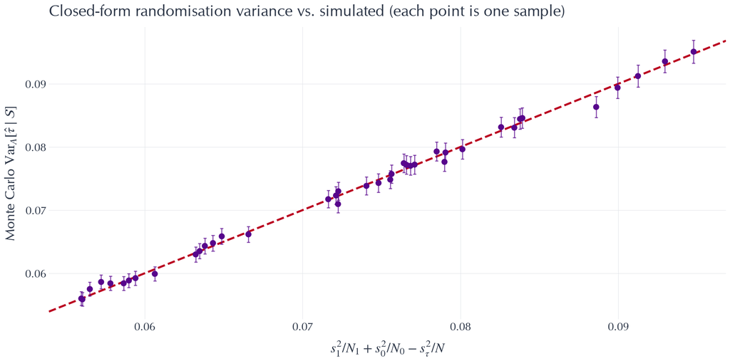

```python
(
    p9.ggplot(study1, p9.aes(x="var_design_exact", y="var_design_mc"))
    + p9.geom_abline(slope=1, intercept=0, color=COLORS["truth"], linetype="dashed", size=1.0)
    + p9.geom_errorbar(
        p9.aes(
            ymin="var_design_mc - 1.96 * var_design_mcse",
            ymax="var_design_mc + 1.96 * var_design_mcse",
        ),
        width=0.0002,
        color=COLORS["estimate"],
        alpha=0.7,
    )
    + p9.geom_point(size=2.0, color=COLORS["estimate"])
    + p9.labs(
        title="Closed-form randomisation variance vs. simulated (each point is one sample)",
        x=r"$s_1^2/N_1 + s_0^2/N_0 - s_\tau^2/N$",
        y=r"Monte Carlo $\mathrm{Var}_A[\hat\tau \mid \mathcal{S}]$",
    )
)
```

### The estimator is unbiased, sample by sample

Each box is the distribution of $\hat{\tau}$ over assignments within one fixed sample. The boxes centre on their own SATE (red), not on the PATE (black dashed).

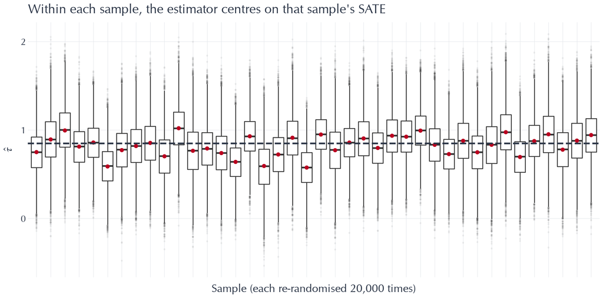

```python
(
    p9.ggplot(study1_long, p9.aes(x="factor(sample)"))
    + p9.geom_boxplot(p9.aes(y="ate_hat"), outlier_alpha=0.05, outlier_size=0.3)
    + p9.geom_point(p9.aes(y="sate"), data=study1, color=COLORS["truth"], size=1.5)
    + p9.geom_hline(yintercept=pate, size=1.0, linetype="dashed", color=COLORS["data"])
    + p9.scale_x_discrete(name="Sample (each re-randomised 20,000 times)", labels=False)
    + p9.labs(
        title="Within each sample, the estimator centres on that sample's SATE",
        y=r"$\hat\tau$",
    )
)
```

### Estimated variance against the truth, for each sample

For each sample, take the ratio of the average estimated variance to the true randomisation variance. If Neyman's estimator were unbiased for the SATE-relevant variance, these would sit on one.

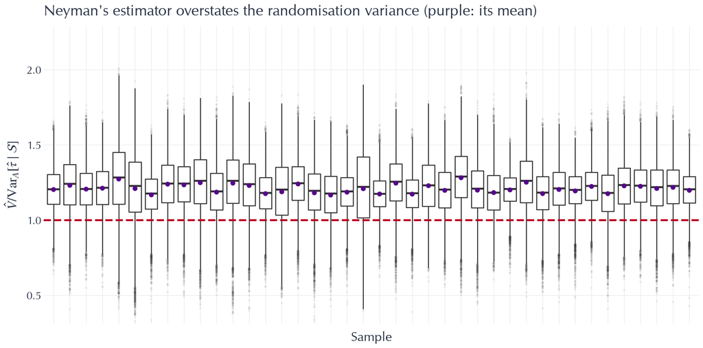

```python
(
    p9.ggplot(study1_long, p9.aes(x="factor(sample)", y="var_hat / var_design_mc"))
    + p9.geom_boxplot(outlier_alpha=0.05, outlier_size=0.3)
    + p9.geom_hline(yintercept=1, linetype="dashed", size=1.0, color=COLORS["truth"])
    + p9.geom_point(
        p9.aes(y="mean_var_hat / var_design_mc"), data=study1, color=COLORS["estimate"], size=1.5
    )
    + p9.scale_x_discrete(name="Sample", labels=False)
    + p9.scale_y_continuous(name=r"$\hat V / \mathrm{Var}_A[\hat\tau \mid \mathcal{S}]$")
    + p9.coord_cartesian(ylim=(0.4, 2.2))
    + p9.labs(title="Neyman's estimator overstates the randomisation variance (purple: its mean)")
)
```

### Why? The gap is the unidentified term

Every purple point sits above one. We can say more than "conservative": the slides claim the bias is exactly $s_\tau^2/N$, so plot one against the other. Each point is a sample, error bars are 95% Monte Carlo intervals, and the dashed line is $y = x$ — drawn, not fitted.

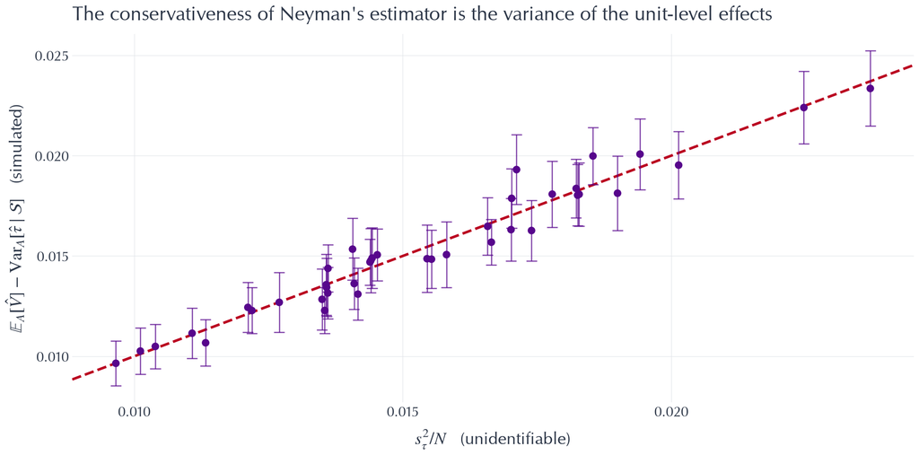

```python
(
    p9.ggplot(study1, p9.aes(x="unidentified", y="gap"))
    + p9.geom_abline(slope=1, intercept=0, color=COLORS["truth"], linetype="dashed", size=1.0)
    + p9.geom_errorbar(
        p9.aes(ymin="gap - 1.96 * gap_mcse", ymax="gap + 1.96 * gap_mcse"),
        width=0.0002,
        color=COLORS["estimate"],
        alpha=0.7,
    )
    + p9.geom_point(size=2.0, color=COLORS["estimate"])
    + p9.labs(
        title="The conservativeness of Neyman's estimator is the variance of the unit-level effects",
        x=r"$s_\tau^2 / N$   (unidentifiable)",
        y=r"$\mathbb{E}_A[\hat V] - \mathrm{Var}_A[\hat\tau \mid \mathcal{S}]$   (simulated)",
    )
)
```

```python
print("Averaged over samples:")
print(f"  E[Vhat]                       {study1['mean_var_hat'].mean():0.5f}")
print(f"  Var_A[tau_hat | S]            {study1['var_design_mc'].mean():0.5f}")
print(f"  difference                    {study1['gap'].mean():0.5f}")
print(f"  s^2_tau / N                   {study1['unidentified'].mean():0.5f}   <-- the same number")
print()
print("  standard errors are overstated by a factor of "
      f"{np.sqrt((study1['mean_var_hat'] / study1['var_design_mc']).mean()):0.3f}")
```

```
Averaged over samples:
  E[Vhat]                       0.08815
  Var_A[tau_hat | S]            0.07281
  difference                    0.01534
  s^2_tau / N                   0.01539   <-- the same number

  standard errors are overstated by a factor of 1.100
```

The conservativeness is a specific quantity, not a vague safety margin: $s_\tau^2/N$, the variance of the individual treatment effects. We can never estimate it, because $\tau_i = Y_i(1) - Y_i(0)$ needs both potential outcomes for the same unit. It enters the true variance with a minus sign, so ignoring it makes us too cautious, never overconfident. That is why we accept it.

Two consequences:

- More effect heterogeneity means more conservative standard errors. If $\tau_i$ were constant, $s_\tau^2 = 0$ and $\hat{V}$ would be unbiased.
- The conservativeness does not shrink relative to the variance. Both terms scale like $1/N$, so the ratio stays put as the sample grows. Study 3 shows this.

## Study 2: total uncertainty

Draw a fresh sample for every replication and randomise once within it. Now both sources of uncertainty are active and the relevant target is the PATE.

Note the change in simulation design. Study 1 needed many assignments per sample to pin down a within-sample variance. Study 2 needs many samples to pin down the total variance. Spending the same budget the other way round would give a noisy answer. Let the aim decide the design.

```python
N_STUDY2 = 50_000

Y0_pop, Y1_pop = P["y0"].to_numpy(), P["y1"].to_numpy()

# One SRSWOR of size N_SAMPLE per replication.
sample_idx = np.stack(
    [rng.choice(N_POPULATION, size=N_SAMPLE, replace=False) for _ in range(N_STUDY2)]
)
y0_draws, y1_draws = Y0_pop[sample_idx], Y1_pop[sample_idx]

sate_study2 = (y1_draws - y0_draws).mean(axis=1)
ate_study2, var_study2 = run_rcts(y0_draws, y1_draws, N_TREATED, rng)
se_study2 = np.sqrt(var_study2)

print(f"{N_STUDY2:,} replications of (draw a sample -> randomise -> estimate)")
```

```
50,000 replications of (draw a sample -> randomise -> estimate)
```

### Is the estimator unbiased for the PATE?

```python
mcse_mean = ate_study2.std(ddof=1) / np.sqrt(N_STUDY2)

print(f"PATE                     {pate:0.5f}")
print(f"mean of tau_hat          {ate_study2.mean():0.5f}")
print(f"Monte Carlo error        {mcse_mean:0.5f}")
print(f"difference, in MC errors  {(ate_study2.mean() - pate) / mcse_mean:+0.2f}")
```

```
PATE                     0.84829
mean of tau_hat          0.84851
Monte Carlo error        0.00134
difference, in MC errors  +0.16
```

Yes, within Monte Carlo error.

### The variance decomposition

The three variances should satisfy the ANOVA decomposition from the slides:

$$\underbrace{\text{Var}[\hat{\tau}]}_{\text{total}} = \underbrace{\mathbb{E}\big[\text{Var}_A[\hat{\tau} \mid \mathcal{S}]\big]}_{\text{design}} + \underbrace{\text{Var}[\tau_{\mathcal{S}}]}_{\text{sampling}}.$$

The sampling and total pieces come straight from these replications. For the design piece we use the closed-form randomisation variance — the formula Study 1 just validated — evaluated on each of the same 50,000 samples and averaged. That is far more precise than averaging Study 1's 40 samples.

```python
var_total = ate_study2.var(ddof=1)
var_sampling = sate_study2.var(ddof=1)

# Closed-form Var_A[tau_hat | S] for each sample, then averaged over samples.
n_control = N_SAMPLE - N_TREATED
s2_1 = y1_draws.var(axis=1, ddof=1)
s2_0 = y0_draws.var(axis=1, ddof=1)
s2_tau = (y1_draws - y0_draws).var(axis=1, ddof=1)
var_design_avg = (s2_1 / N_TREATED + s2_0 / n_control - s2_tau / N_SAMPLE).mean()

print(f"total,    Var[tau_hat]           {var_total:0.5f}")
print(f"design,   E[Var_A[tau_hat | S]]  {var_design_avg:0.5f}")
print(f"sampling, Var[SATE]              {var_sampling:0.5f}")
print(f"design + sampling                {var_design_avg + var_sampling:0.5f}")
```

```
total,    Var[tau_hat]           0.08925
design,   E[Var_A[tau_hat | S]]  0.07427
sampling, Var[SATE]              0.01493
design + sampling                0.08920
```

### One estimator, two targets

Now compare Neyman's $\hat{V}$ to the total variance and to the design variance alone. That comparison is the point of the lecture.

```python
mean_var_hat = var_study2.mean()

print(f"E[Vhat]                          {mean_var_hat:0.5f}")
print()
print(f"E[Vhat] / Var[tau_hat]           {mean_var_hat / var_total:0.4f}   <-- PATE inference")
print(f"E[Vhat] / E[Var_A[tau_hat | S]]  {mean_var_hat / var_design_avg:0.4f}   <-- SATE inference")
```

```
E[Vhat]                          0.08978

E[Vhat] / Var[tau_hat]           1.0060   <-- PATE inference
E[Vhat] / E[Var_A[tau_hat | S]]  1.2087   <-- SATE inference
```

The same $\hat{V}$ is right for the total variance and about 20% too large for the design variance. Nothing about the estimator changed, only the question asked of it.

### Does that give honest confidence intervals?

Variance ratios are abstract. Coverage is what a reader relies on: does the nominal 95% interval $\hat{\tau} \pm 1.96\sqrt{\hat{V}}$ contain the target 95% of the time?

```python
Z95 = 1.959964

cover_pate = np.mean(np.abs(ate_study2 - pate) <= Z95 * se_study2)
cover_sate = np.mean(np.abs(ate_study2 - sate_study2) <= Z95 * se_study2)
mcse_cover = np.sqrt(0.95 * 0.05 / N_STUDY2)

print(f"nominal                  95.0%")
print(f"coverage of the PATE     {100 * cover_pate:0.1f}%")
print(f"coverage of the SATE     {100 * cover_sate:0.1f}%")
print(f"Monte Carlo error        +/- {100 * 1.96 * mcse_cover:0.1f} points")
```

```
nominal                  95.0%
coverage of the PATE     93.7%
coverage of the SATE     95.9%
Monte Carlo error        +/- 0.2 points
```

The SATE is covered more often than advertised. That is the conservativeness, in the units we care about. Intervals that are too wide cost power, but they do not mislead.

## Study 3: consistency, and what it does not fix

Everything so far held $N = 40$. The slides claim $\hat{\tau}$ is consistent for both the SATE and the PATE in $N_1, N_0$: the sampling distribution collapses onto the target as the arms grow. We run the whole simulation at a ladder of sample sizes and look at how the results change with $N$.

One change of framing: consistency is about $N \to \infty$, so a fixed population of 2,000 will not do. We let the population be effectively infinite by drawing each sample straight from the DGP, which is superpopulation inference. The target is then the superpopulation ATE, known exactly.

For each $N$, over 10,000 replications, we record bias with its Monte Carlo error, the spread of $\hat{\tau}$ around the ATE and around the SATE, the average estimated SE, and coverage for both targets.

```python
def learning_curve_row(n, reps, rng, treated_share=0.5, cell_budget=4_000_000):
    """Run `reps` full replications (fresh sample -> randomise -> estimate) at size n."""
    n1 = int(round(n * treated_share))

    # Work in blocks so the (reps x n) arrays stay a sane size in memory.
    block = max(1, cell_budget // n)
    ate, var_hat, sate = [], [], []
    remaining = reps
    while remaining > 0:
        b = min(block, remaining)
        _, y0, y1 = draw_potential_outcomes((b, n), rng)
        t, v = run_rcts(y0, y1, n1, rng)
        ate.append(t)
        var_hat.append(v)
        sate.append((y1 - y0).mean(axis=1))
        remaining -= b

    ate = np.concatenate(ate)
    var_hat = np.concatenate(var_hat)
    sate = np.concatenate(sate)
    se = np.sqrt(var_hat)

    return {
        "n": n,
        "bias": ate.mean() - ATE_SUPERPOPULATION,
        "mcse_bias": ate.std(ddof=1) / np.sqrt(reps),
        "sd_total": ate.std(ddof=1),
        "sd_design": (ate - sate).std(ddof=1),
        "mean_se_hat": se.mean(),
        "coverage_ate": np.mean(np.abs(ate - ATE_SUPERPOPULATION) <= Z95 * se),
        "coverage_sate": np.mean(np.abs(ate - sate) <= Z95 * se),
    }
```

```python
N_GRID = [20, 40, 80, 160, 320, 640, 1280, 2560]
REPS_PER_N = 10_000

curves = pl.from_dicts([learning_curve_row(n, REPS_PER_N, rng) for n in N_GRID])
print(f"{len(N_GRID)} sample sizes x {REPS_PER_N:,} replications")
```

```
8 sample sizes x 10,000 replications
```

### Bias does not depend on N

Unbiasedness and consistency are different claims. Unbiasedness holds at every $N$, including $N = 20$; no large sample is needed. The error bars are Monte Carlo error. With eight sample sizes you should expect one or two points to sit a couple of bars from zero — if you find yourself explaining such a point substantively, you have mistaken simulation noise for a finding.

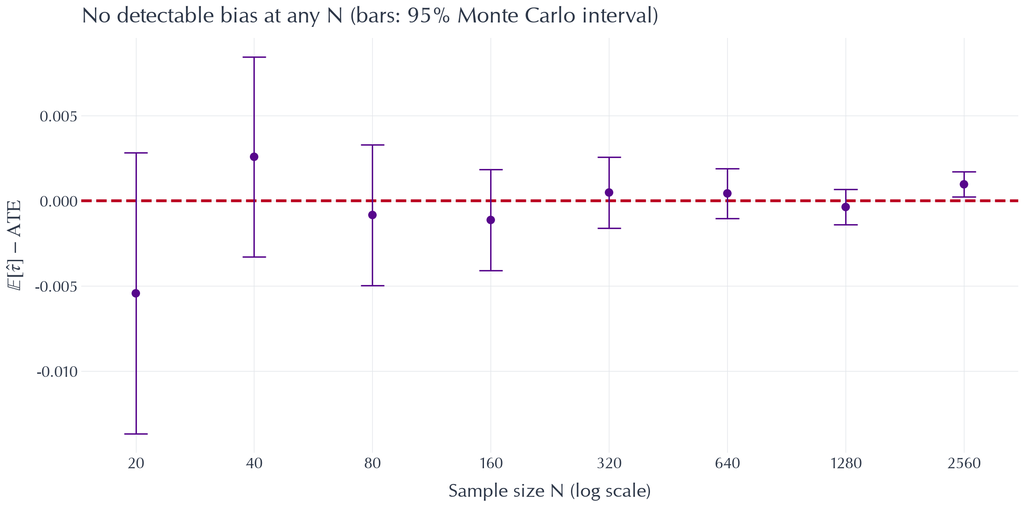

```python
(
    p9.ggplot(curves, p9.aes(x="n", y="bias"))
    + p9.geom_hline(yintercept=0, color=COLORS["truth"], linetype="dashed", size=1.0)
    + p9.geom_errorbar(
        p9.aes(ymin="bias - 1.96 * mcse_bias", ymax="bias + 1.96 * mcse_bias"),
        width=0.06,
        color=COLORS["estimate"],
    )
    + p9.geom_point(size=2.0, color=COLORS["estimate"])
    + p9.scale_x_log10(breaks=N_GRID, labels=[str(n) for n in N_GRID])
    + p9.labs(
        title="No detectable bias at any N (bars: 95% Monte Carlo interval)",
        x="Sample size N (log scale)",
        y=r"$\mathbb{E}[\hat\tau] - \mathrm{ATE}$",
    )
)
```

### Spread shrinks; the gap between the two targets does not

Read the table by column. `SD vs ATE` and `SD vs SATE` both fall by a factor of $\sqrt{2}$ every time $N$ doubles, which is consistency at the $\sqrt{N}$ rate. `Est. SE` tracks `SD vs ATE`, so the last two columns are the summary: Neyman's estimator is right for the total variance at every $N$, and about 9% too large as a standard error for the SATE at every $N$. That ratio does not move.

```python
curves.select(
    N="n",
    Bias=pl.col("bias").round(5),
    **{"MC error": pl.col("mcse_bias").round(5)},
    **{"SD vs ATE": pl.col("sd_total").round(4)},
    **{"SD vs SATE": pl.col("sd_design").round(4)},
    **{"Est. SE": pl.col("mean_se_hat").round(4)},
    **{"SE / SD(ATE)": (pl.col("mean_se_hat") / pl.col("sd_total")).round(3)},
    **{"SE / SD(SATE)": (pl.col("mean_se_hat") / pl.col("sd_design")).round(3)},
)
```

shape: (8, 8)

| N i64 | Bias f64 | MC error f64 | SD vs ATE f64 | SD vs SATE f64 | Est. SE f64 | SE / SD(ATE) f64 | SE / SD(SATE) f64 |
| --- | --- | --- | --- | --- | --- | --- | --- |
| 20 | -0.00544 | 0.00421 | 0.4212 | 0.3851 | 0.4181 | 0.993 | 1.086 |
| 40 | 0.00258 | 0.003 | 0.2996 | 0.2706 | 0.2979 | 0.994 | 1.101 |
| 80 | -0.00083 | 0.00211 | 0.2109 | 0.1925 | 0.2109 | 1.0 | 1.096 |
| 160 | -0.00113 | 0.00152 | 0.1516 | 0.1381 | 0.1495 | 0.986 | 1.082 |
| 320 | 0.00049 | 0.00106 | 0.1063 | 0.0963 | 0.1057 | 0.994 | 1.098 |
| 640 | 0.00043 | 0.00075 | 0.075 | 0.0688 | 0.0748 | 0.997 | 1.088 |
| 1280 | -0.00036 | 0.00053 | 0.0529 | 0.0481 | 0.0529 | 1.001 | 1.1 |
| 2560 | 0.00097 | 0.00038 | 0.0375 | 0.0342 | 0.0374 | 0.998 | 1.095 |

### Coverage

Coverage of the ATE climbs to 95% and stays there: the shortfall at small $N$ was the normal approximation, and consistency repairs it. Coverage of the SATE climbs past 95% and settles above it. That is not a small-sample artefact and it does not go away — it is the unidentifiable $s_\tau^2/N$ term, showing up where a reader would notice.

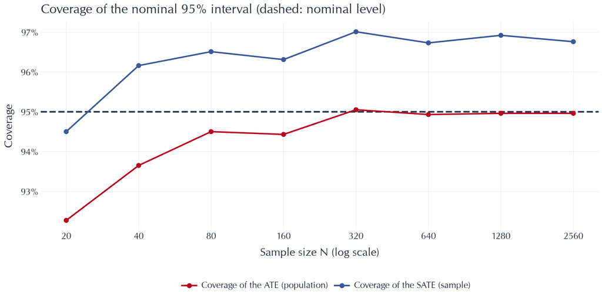

```python
cover_labels = {
    "coverage_ate": "Coverage of the ATE (population)",
    "coverage_sate": "Coverage of the SATE (sample)",
}
coverage = (
    curves.select(["n", "coverage_ate", "coverage_sate"])
    .unpivot(index="n", variable_name="target", value_name="coverage")
    .with_columns(target=pl.col("target").replace_strict(cover_labels))
)

(
    p9.ggplot(coverage, p9.aes(x="n", y="coverage", color="target"))
    + p9.geom_hline(yintercept=0.95, linetype="dashed", size=1.0, color=COLORS["data"])
    + p9.geom_line(size=0.9)
    + p9.geom_point(size=2.0)
    + p9.scale_color_manual(values={
        cover_labels["coverage_ate"]: COLORS["truth"],
        cover_labels["coverage_sate"]: COLORS["control"],
    })
    + p9.scale_x_log10(breaks=N_GRID, labels=[str(n) for n in N_GRID])
    + p9.scale_y_continuous(labels=lambda vals: [f"{100 * v:0.0f}%" for v in vals])
    + p9.labs(
        title="Coverage of the nominal 95% interval (dashed: nominal level)",
        x="Sample size N (log scale)",
        y="Coverage",
        color="",
    )
)
```

## What to take away

1. **The difference in means is unbiased for both the SATE and the PATE, at every sample size.** Study 1 showed it centring on each sample's SATE, Study 2 on the PATE, Study 3 that this needs no large sample.
2. **Neyman's $\hat{V} = s_1^2/N_1 + s_0^2/N_0$ is unbiased for the total variance and conservative for the design variance.** One estimator, two targets. Which of the three interpretations from the slides applies depends on the question you asked, not on the data.
3. **The conservativeness is exactly $s_\tau^2/N$, the variance of the unit-level effects.** The gap plot showed this. We cannot estimate $s_\tau^2$, because it needs both potential outcomes for the same unit. It enters the true variance with a minus sign, so heterogeneous effects can only make us too cautious, never overconfident. With constant effects, $\hat{V}$ would be right for the SATE too.
4. **Consistency shrinks the variance, not the conservativeness.** Spread falls at the $\sqrt{N}$ rate and PATE coverage converges to 95%, but SATE coverage settles above 95% and stays there. A bigger experiment does not buy an honest SATE standard error.

So: a standard error means nothing until you say which population it refers to. Everything later in the course — covariate adjustment, weighting, double machine learning — shrinks the identified part of the variance. None of it touches the unidentified part.

## Things to try / think about

- **Monte Carlo error.** Every number here has some. Re-run with a different seed and see which conclusions move. Set `N_ASSIGNMENTS` to 100 and watch the Study 1 result dissolve into noise.
- **Change the DGP.**
  - What happens as you change $|\mathcal{U}|$, $N$, and $N_1/N$?
  - What controls how conservative the estimator is? Make the effect constant ($Y_i(1) = \tau + Y_i(0)$, i.e. share the noise draw between the two potential outcomes) and predict what happens to the gap plot before running it.
  - Try an unbalanced design, $N_1/N = 0.1$. Does the conservativeness change? Does coverage?
- **The finite-population correction.** We chose $N/|\mathcal{U}| = 2\%$ to ignore it. Set `N_POPULATION = 60` with `N_SAMPLE = 40` and re-run Study 2. Neyman's estimator should now be conservative for the PATE as well. Why, given $\text{Var}[\tau_{\mathcal{S}}] = (1 - N/|\mathcal{U}|)\,\sigma^2_\tau/N$?
- **Other variance estimators.**
  - The nonparametric bootstrap, resampling $N_1$ treated and $N_0$ control units. How close is it?
  - The sharp variance estimator of [Aronow, Green and Lee](https://arxiv.org/abs/1405.6555), which bounds $s_\tau^2$ rather than ignoring it. Where does it land between our two targets?
  - HC2 robust standard errors from a regression of $Y$ on $A$. They should match $\hat{V}$ almost exactly.
- **Better intervals at small $N$.** Replace $1.96$ with a $t_{N-2}$ quantile and redo the coverage chart. How much of the small-$N$ shortfall does that recover?
- **A different estimand.** Everything here is about averages. Is the difference in means unbiased for the median treatment effect? (Careful: what would that even mean?)